# Reproducible Research Peer Assignment 2

Antonio Vitor Villas Boas

April 26th 2021

# Impacts of Weather Occurrences in the USA: an Economic and Health analysis

## Synopsis

Severe weather occurrences in the USA are reported monthly by [NOAA](https://www.noaa.gov/). Those reports helps us discover most harmful and fatal weather events so preventing actions can be taken, whether to avoid any casualties or mitigate the damages.

This report will analyze which events produces the greatest economic and health impacts on the society.

## Loading and preprocessing the data

The data used for this assignment can be downloaded from this [link](https://d396qusza40orc.cloudfront.net/repdata%2Fdata%2FStormData.csv.bz2)

There is also some documentation of the database available. Here you will find how some of the variables are constructed/defined.

- National Weather Service [Storm Data Documentation](https://d396qusza40orc.cloudfront.net/repdata%2Fpeer2_doc%2Fpd01016005curr.pdf)
- National Climatic Data Center Storm Events [FAQ](https://d396qusza40orc.cloudfront.net/repdata%2Fpeer2_doc%2FNCDC%20Storm%20Events-FAQ%20Page.pdf)

```r
if (!("stormdata" %in% ls())){
     if (!file.exists("repdata_data_StormData.csv.bz2")){
          fileURL <- "https://d396qusza40orc.cloudfront.net/repdata%2Fdata%2FStormData.csv.bz2"
          download.file(fileURL,
                        destfile = "repdata_data_StormData.csv.bz2")
     }

     stormdata <- read.csv("repdata_data_StormData.csv.bz2",
                           na.strings = c("", "NA", "NULL"))
}
```

Let’s load the libraries we need

```r
library(dplyr)
library(ggplot2)
library(lubridate)
library(tidyverse)
```

## Results

### 1. Across the United States, which types of events (as indicated in the EVTYPE variable) are most harmful with respect to population health?

1st let’s analyze which weather event caused the most fatalities:

```r
fatal <- aggregate(FATALITIES ~ EVTYPE,
                   data = stormdata,
                   FUN = sum) %>%
     arrange(desc(FATALITIES)) %>%
     head(10)

fatal$EVTYPE <- factor(fatal$EVTYPE,
                       levels = fatal$EVTYPE)

injury <- aggregate(INJURIES ~ EVTYPE,
                    data = stormdata,
                    FUN = sum) %>%
     arrange(desc(INJURIES)) %>%
     head(10)

injury$EVTYPE <- factor(injury$EVTYPE,
                       levels = injury$EVTYPE)
```

Now let’s see which weather event caused the most injuries:

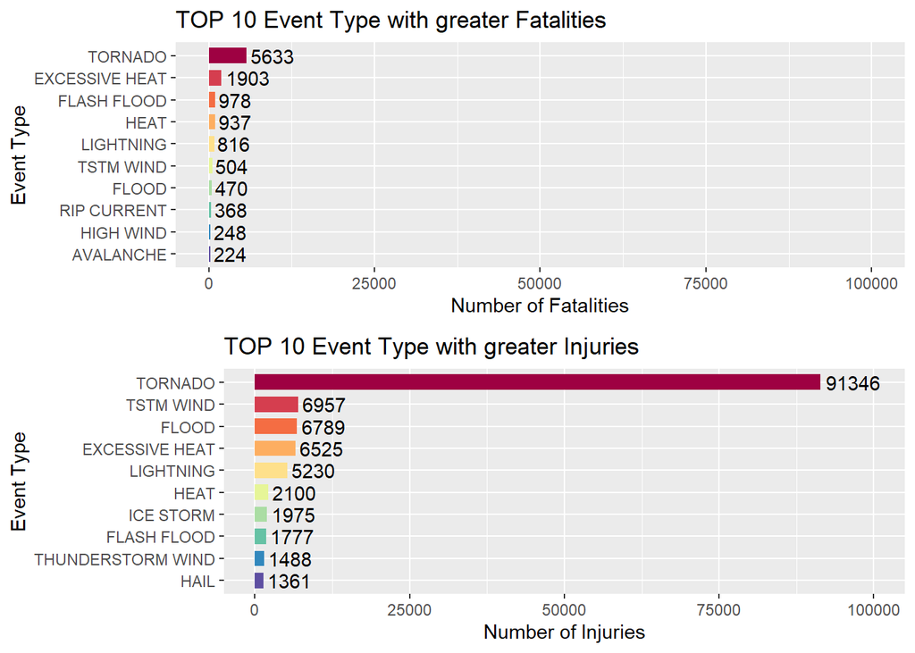

```r
library(ggpubr)
fat <- ggplot(data = fatal,
              aes(x = fct_reorder(EVTYPE,
                                  FATALITIES),
                  y = FATALITIES)) +
     geom_col(aes(fill = EVTYPE),
              width = 0.7) +
     geom_text(aes(label = FATALITIES),
               hjust = -0.1) +
     scale_y_continuous(limits = c(0, 1E5)) +
     coord_flip() +
     labs(title = "TOP 10 Event Type with greater Fatalities",
          y = "Number of Fatalities",
          x = "Event Type") +
     scale_fill_brewer(palette = "Spectral") +
     theme(legend.position = "none")

inj <- ggplot(data = injury,
              aes(x = fct_reorder(EVTYPE,
                                  INJURIES),
                  y = INJURIES)) +
     geom_col(aes(fill = EVTYPE),
              width = 0.7) +
     geom_text(aes(label = INJURIES),
               hjust = -0.1) +
     scale_y_continuous(limits = c(0, 1E5)) +
     coord_flip() +
     labs(title = "TOP 10 Event Type with greater Injuries",
          y = "Number of Injuries",
          x = "Event Type") +
     scale_fill_brewer(palette = "Spectral") +
     theme(legend.position = "none")

ggarrange(fat, inj, nrow = 2)
```

TORNADO seems to be the most dangerous weather event.

So another question can be raised with this information. Have the impacts of tornado events been mitigated over time?

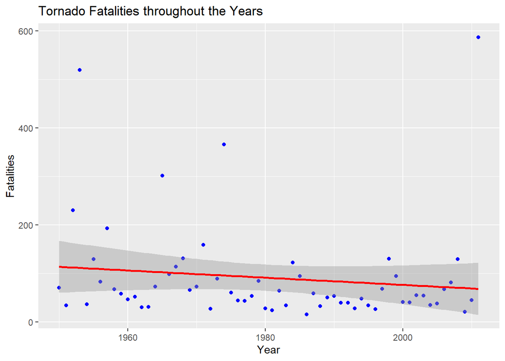

```r
worst_event <- as.character(fatal$EVTYPE[which.max(fatal$FATALITIES)])

tornado <- subset(stormdata, EVTYPE == worst_event)

tornado$BGN_DATE <- tornado$BGN_DATE %>%
     str_remove(pattern = "0:00:00") %>%
     mdy()

tornado <- mutate(tornado,
                  MONTH = month(BGN_DATE),
                  YEAR = year(BGN_DATE))

fatal_tornados_yearly <- aggregate(FATALITIES ~ YEAR,
                                   data = tornado,
                                   FUN = sum)

ggplot(fatal_tornados_yearly,
       aes(x = YEAR,
           y = FATALITIES)) +
     geom_point(col = "blue") +
     geom_smooth(method = "lm",
                 col = "red",
                 size = 1) +
     labs(title = "Tornado Fatalities throughout the Years",
          x = "Year",
          y = "Fatalities")
```

Well, tornado events are indeed hard to mitigate its impacts, but in this dataset we can notice a slight downward trend on the red line that indicates that the number of fatalities has decreased throughout the years.

### 2. Across the United States, which types of events have the greatest economic consequences?

The economic impacts of weather events are estimated as actual dollar amounts from an insurance company and is divided in:

- Property Damage
- Crop Damage

each type of damage has its respective exponential:

- k = 1.000 ($10^3$)
- m = 1.000.000 ($10^6$)
- b = 1.000.000.000 ($10^9$)

Prior analyzing these impacts, we must multiply the damage amounts by its exponential according to this formula:

DAMAGE AMOUNT $\times$ $10^{EXP}$

```r
economy_dmg <- select(stormdata,
                      STATE, EVTYPE, PROPDMG, PROPDMGEXP, CROPDMG, CROPDMGEXP)
for(i in 1:length(economy_dmg)) {
        if (class(economy_dmg[,i]) == "character"){
                economy_dmg[,i] <- tolower(economy_dmg[,i])
        }
}

# Changing the magnitudes of Property Damages
economy_dmg$PROPDMGEXP[economy_dmg$PROPDMGEXP == "k"] <- 3
economy_dmg$PROPDMGEXP[economy_dmg$PROPDMGEXP == "m"] <- 6
economy_dmg$PROPDMGEXP[economy_dmg$PROPDMGEXP == "b"] <- 9

economy_dmg$PROPDMGEXP <- as.numeric(economy_dmg$PROPDMGEXP)
economy_dmg$PROPDMGEXP[is.na(economy_dmg$PROPDMGEXP)] <- 0

# Changing the magnitudes of Crop Damages
economy_dmg$CROPDMGEXP[economy_dmg$CROPDMGEXP == "k"] <- 3
economy_dmg$CROPDMGEXP[economy_dmg$CROPDMGEXP == "m"] <- 6
economy_dmg$CROPDMGEXP[economy_dmg$CROPDMGEXP == "b"] <- 9

economy_dmg$CROPDMGEXP <- as.numeric(economy_dmg$CROPDMGEXP)
economy_dmg$CROPDMGEXP[is.na(economy_dmg$CROPDMGEXP)] <- 0

# this will apply the exponential to its damage amount in every row
for (i in 0:9) {
        economy_dmg$PROPDMG[economy_dmg$PROPDMGEXP == i] <- economy_dmg$PROPDMG[economy_dmg$PROPDMGEXP == i] * 10^i

        economy_dmg$CROPDMG[economy_dmg$CROPDMGEXP == i] <- economy_dmg$CROPDMG[economy_dmg$CROPDMGEXP == i] * 10^i
}

economy_dmg <- select(economy_dmg,
                      -c(PROPDMGEXP, CROPDMGEXP)) %>%
        mutate(TOTAL = PROPDMG + CROPDMG)

head(economy_dmg)
```

```
##   STATE  EVTYPE PROPDMG CROPDMG TOTAL
## 1    al tornado   25000       0 25000
## 2    al tornado    2500       0  2500
## 3    al tornado   25000       0 25000
## 4    al tornado    2500       0  2500
## 5    al tornado    2500       0  2500
## 6    al tornado    2500       0  2500
```

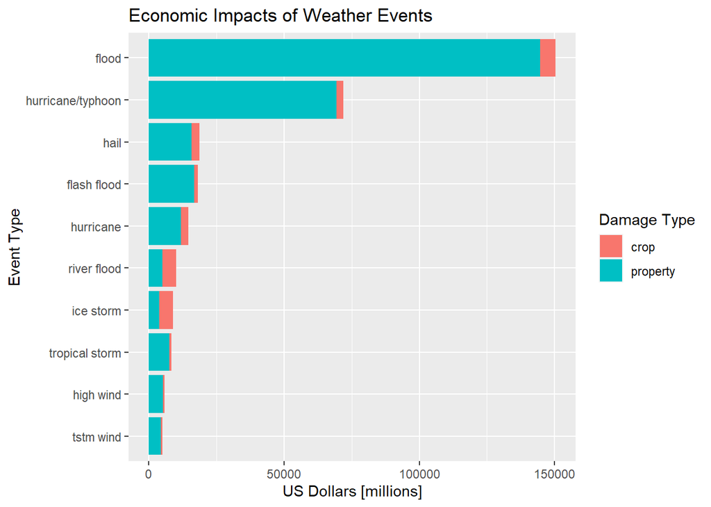

```r
prop_dmg <- aggregate(PROPDMG ~ EVTYPE,
                      data = economy_dmg,
                      FUN = sum) %>%
        arrange(desc(PROPDMG)) %>%
        mutate(DDMGTYPE = "property")

crop_dmg <- aggregate(CROPDMG ~ EVTYPE,
                      data = economy_dmg,
                      FUN = sum) %>%
        arrange(desc(CROPDMG)) %>%
        mutate(DDMGTYPE = "crop")

most_expensive_events <- intersect(prop_dmg[1:15, 1],
                                   crop_dmg[1:15, 1])
prop_dmg <- subset(prop_dmg,
                       EVTYPE %in% most_expensive_events)
crop_dmg <- subset(crop_dmg,
                       EVTYPE %in% most_expensive_events)

names(prop_dmg) <- c("EVTYPE", "COUNT", "DMGTYPE")
names(crop_dmg) <- c("EVTYPE", "COUNT", "DMGTYPE")

eco_dmg <- rbind(prop_dmg, crop_dmg)

ggplot(data = eco_dmg,
       aes(x = fct_reorder(EVTYPE,
                           COUNT),
           y = COUNT/1E6, # in millions
           fill = DMGTYPE)) +
        geom_col() +
        coord_flip() +
        labs(title = "Economic Impacts of Weather Events",
             y = "US Dollars [millions]",
             x = "Event Type",
             fill = "Damage Type")
```

### 3. Which States are most affected by weather events?

This questions isn’t among the 2 of this assignment. This is just a “out of curiosity” question that came up while I was analyzing.

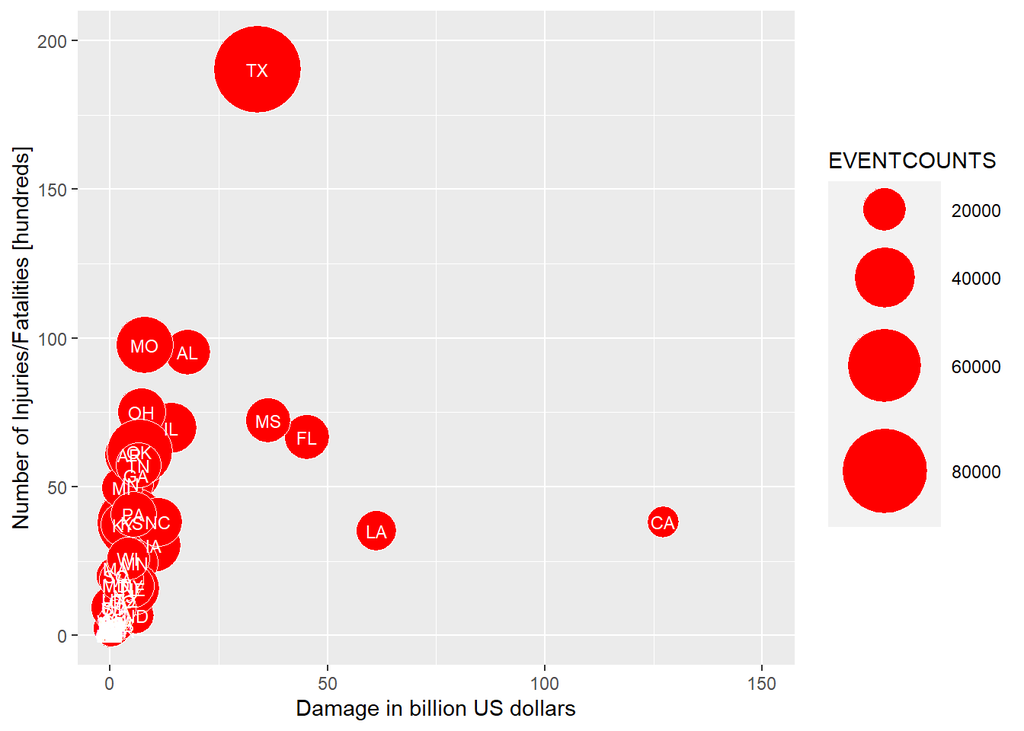

```r
storm2 <- cbind(economy_dmg, select(stormdata,
                                    FATALITIES, INJURIES))

# number of events that happened in each State
eventcount <- aggregate(stormdata$STATE,
                            by = list(STATE=stormdata$STATE),
                            FUN = NROW)

states <- with(storm2,
               aggregate(list(PROPDMG, CROPDMG, FATALITIES, INJURIES),
                         by = list(STATE=stormdata$STATE),
                         FUN = sum))

states <- merge(states, eventcount,
                by = "STATE")
names(states) <- c("STATE", "PROPDMG", "CROPDMG", "FATALITIES", "INJURIES", "EVENTCOUNTS")

states <- mutate(states,
                 COST = (PROPDMG + CROPDMG)/1E9, # in millions of USD
                 HARM = (FATALITIES + INJURIES)/100)
ggplot(states,
       aes(x = COST,
           y = HARM,
           size = EVENTCOUNTS,
           label = STATE)) +
        geom_point(colour = "white",
                   fill = "red",
                   shape = 21) +
        geom_text(size = 3,
                  color = "white") +
        scale_x_continuous(name = "Damage in billion US dollars",
                           limits = c(0,150)) +
        scale_y_continuous(name = "Number of Injuries/Fatalities [hundreds]",
                           limits = c(0,200)) +
        scale_size_area(max_size = 20)
```

last update: May 02 2021 - 22h15